# Course project machine learning

# Elaborating data and prediction

### Training three models

```r
library(randomForest)
library(gbm)
#bagging: we use 52 predictors, 500 n.trees
bag.model<-randomForest(classe~., data=training, mtry=52, importance=TRUE)
bag.model
```

```
##
## Call:
##  randomForest(formula = classe ~ ., data = training, mtry = 52,      importance = TRUE)
##                Type of random forest: classification
##                      Number of trees: 500
## No. of variables tried at each split: 52
##
##         OOB estimate of  error rate: 1.4%
## Confusion matrix:
##      A    B    C    D    E class.error
## A 3885   11    7    1    2 0.005376344
## B   35 2598   18    4    3 0.022573363
## C    7   17 2352   19    1 0.018363940
## D    1    4   35 2208    4 0.019538188
## E    0    6    8    9 2502 0.009108911
```

```r
#randomForest: we use m=7 about sqrt(52) predictors, 500 n.trees
rf.model<-randomForest(classe~., data=training, importance=TRUE)
rf.model
```

```
##
## Call:
##  randomForest(formula = classe ~ ., data = training, importance = TRUE)
##                Type of random forest: classification
##                      Number of trees: 500
## No. of variables tried at each split: 7
##
##         OOB estimate of  error rate: 0.53%
## Confusion matrix:
##      A    B    C    D    E class.error
## A 3899    5    1    0    1 0.001792115
## B   12 2642    4    0    0 0.006019564
## C    0   13 2379    4    0 0.007095159
## D    0    0   24 2226    2 0.011545293
## E    0    0    1    6 2518 0.002772277
```

```r
#boosting: we use cross validation with k=10 folds, 150 n.trees, interaction.depth=3, shrinkage=0.1
boost.model<-train(classe~., method="gbm", data=training, verbose=F, trControl = trainControl(method = "cv", number = 10))
boost.model
```

```
## Stochastic Gradient Boosting
##
## 13737 samples
##    52 predictor
##     5 classes: 'A', 'B', 'C', 'D', 'E'
##
## No pre-processing
## Resampling: Cross-Validated (10 fold)
## Summary of sample sizes: 12363, 12364, 12362, 12364, 12363, 12362, ...
## Resampling results across tuning parameters:
##
##   interaction.depth  n.trees  Accuracy   Kappa
##   1                   50      0.7514022  0.6847606
##   1                  100      0.8240515  0.7772809
##   1                  150      0.8530973  0.8140217
##   2                   50      0.8560107  0.8175676
##   2                  100      0.9068945  0.8821711
##   2                  150      0.9318630  0.9137811
##   3                   50      0.8926986  0.8641283
##   3                  100      0.9425655  0.9273215
##   3                  150      0.9614928  0.9512805
##
## Tuning parameter 'shrinkage' was held constant at a value of 0.1
##
## Tuning parameter 'n.minobsinnode' was held constant at a value of 10
## Accuracy was used to select the optimal model using  the largest value.
## The final values used for the model were n.trees = 150,
##  interaction.depth = 3, shrinkage = 0.1 and n.minobsinnode = 10.
```

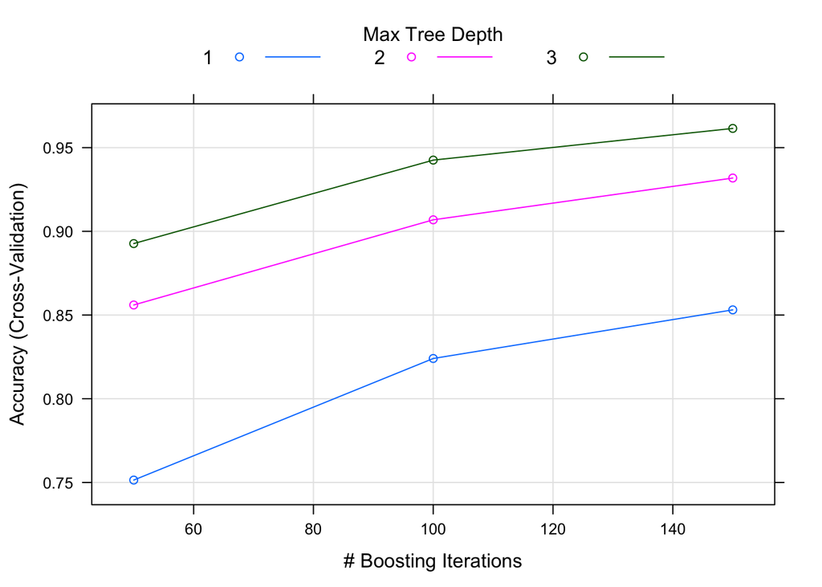

```r
plot(boost.model)
```

### Prediction of the three models

```r
#bagging
yhat.bag<-predict(bag.model, newdata=testing)
confusionMatrix(yhat.bag, testing$classe)
```

```
## Confusion Matrix and Statistics
##
##           Reference
## Prediction    A    B    C    D    E
##          A 1658    8    2    1    0
##          B   10 1125   15    2    2
##          C    4    4 1005   16    2
##          D    0    1    2  942    2
##          E    2    1    2    3 1076
##
## Overall Statistics
##
##                Accuracy : 0.9866
##                  95% CI : (0.9833, 0.9894)
##     No Information Rate : 0.2845
##     P-Value [Acc > NIR] : < 2e-16
##
##                   Kappa : 0.983
##  Mcnemar's Test P-Value : 0.01504
##
## Statistics by Class:
##
##                      Class: A Class: B Class: C Class: D Class: E
## Sensitivity            0.9904   0.9877   0.9795   0.9772   0.9945
## Specificity            0.9974   0.9939   0.9946   0.9990   0.9983
## Pos Pred Value         0.9934   0.9749   0.9748   0.9947   0.9926
## Neg Pred Value         0.9962   0.9970   0.9957   0.9955   0.9988
## Prevalence             0.2845   0.1935   0.1743   0.1638   0.1839
## Detection Rate         0.2817   0.1912   0.1708   0.1601   0.1828
## Detection Prevalence   0.2836   0.1961   0.1752   0.1609   0.1842
## Balanced Accuracy      0.9939   0.9908   0.9871   0.9881   0.9964
```

```r
#randomForest
yhat.rf<-predict(rf.model, newdata=testing)
confusionMatrix(yhat.rf, testing$classe)
```

```
## Confusion Matrix and Statistics
##
##           Reference
## Prediction    A    B    C    D    E
##          A 1672    2    0    0    0
##          B    1 1137   10    0    0
##          C    0    0 1014    9    0
##          D    0    0    2  954    2
##          E    1    0    0    1 1080
##
## Overall Statistics
##
##                Accuracy : 0.9952
##                  95% CI : (0.9931, 0.9968)
##     No Information Rate : 0.2845
##     P-Value [Acc > NIR] : < 2.2e-16
##
##                   Kappa : 0.994
##  Mcnemar's Test P-Value : NA
##
## Statistics by Class:
##
##                      Class: A Class: B Class: C Class: D Class: E
## Sensitivity            0.9988   0.9982   0.9883   0.9896   0.9982
## Specificity            0.9995   0.9977   0.9981   0.9992   0.9996
## Pos Pred Value         0.9988   0.9904   0.9912   0.9958   0.9982
## Neg Pred Value         0.9995   0.9996   0.9975   0.9980   0.9996
## Prevalence             0.2845   0.1935   0.1743   0.1638   0.1839
## Detection Rate         0.2841   0.1932   0.1723   0.1621   0.1835
## Detection Prevalence   0.2845   0.1951   0.1738   0.1628   0.1839
## Balanced Accuracy      0.9992   0.9980   0.9932   0.9944   0.9989
```

```r
#boosting
yhat.boost<-predict(boost.model, testing)
confusionMatrix(yhat.boost, testing$classe)
```

```
## Confusion Matrix and Statistics
##
##           Reference
## Prediction    A    B    C    D    E
##          A 1640   30    0    1    2
##          B   19 1080   37    1   16
##          C    9   29  977   41   11
##          D    1    0   10  915    8
##          E    5    0    2    6 1045
##
## Overall Statistics
##
##                Accuracy : 0.9613
##                  95% CI : (0.956, 0.966)
##     No Information Rate : 0.2845
##     P-Value [Acc > NIR] : < 2.2e-16
##
##                   Kappa : 0.951
##  Mcnemar's Test P-Value : 1.979e-08
##
## Statistics by Class:
##
##                      Class: A Class: B Class: C Class: D Class: E
## Sensitivity            0.9797   0.9482   0.9522   0.9492   0.9658
## Specificity            0.9922   0.9846   0.9815   0.9961   0.9973
## Pos Pred Value         0.9803   0.9367   0.9157   0.9797   0.9877
## Neg Pred Value         0.9919   0.9875   0.9898   0.9901   0.9923
## Prevalence             0.2845   0.1935   0.1743   0.1638   0.1839
## Detection Rate         0.2787   0.1835   0.1660   0.1555   0.1776
## Detection Prevalence   0.2843   0.1959   0.1813   0.1587   0.1798
## Balanced Accuracy      0.9859   0.9664   0.9669   0.9727   0.9815
```

# Conclusions

### Analysis of the three models

All the three models performe well, in fact all of them have high prediction accuracy on validation set. The best one, however, is the random forest model with a OOB estimate of error rate equal to 0.53%, while, when the model is applied to the validation dataset, both the accuracy and k-value overcome the value of 99%. Consequently we decided to apply the random forest model to the analysis of the 20 observations testing set.

### Prediction on 20 testing samples

```r
#randomForest
yhat.rf2<-predict(rf.model, newdata=data.testing)
yhat.rf2
```

```
##  1  2  3  4  5  6  7  8  9 10 11 12 13 14 15 16 17 18 19 20
##  B  A  B  A  A  E  D  B  A  A  B  C  B  A  E  E  A  B  B  B
## Levels: A B C D E
```

# References

Velloso, E.; Bulling, A.; Gellersen, H.; Ugulino, W.; Fuks, H. Qualitative Activity Recognition of Weight Lifting Exercises. Proceedings of 4th International Conference in Cooperation with SIGCHI (Augmented Human ’13) . Stuttgart, Germany: ACM SIGCHI, 2013.

Website for the Groupware@LES Human Activity Recognition project.

An Introduction to Statistical Learning, G. James, D. Witten, T. Hastie, R. Tibshirani. Ed. Springer Verlag (2013). ISBN: 978-1-4614-7138-7.

The Elements of Statistical Learning (2nd. Edition, 10th printing), T. Hastie, R. Tibshirani, J. Friedman. Ed. Springer Verlag (2009). ISBN: 978-0-3878-4857-0.